# Jessica Judson’s R Notebook

```r
setwd("/Users/jessicajudson/Desktop/EEOB546X/Assignment_2")
```

# Part 1

## Data Inspection

**1. Load the files from the Unix assignment into R**

```r
genotypes <- read.table("fang_et_al_genotypes.txt", header = TRUE, sep="\t", stringsAsFactors = FALSE)
position <- read.table("snp_position.txt", header = TRUE, fill = TRUE, sep="\t", stringsAsFactors = FALSE)
```

**2. Inspect the files using various commands**

```r
file.info("fang_et_al_genotypes.txt")
file.info("snp_position.txt")
typeof(genotypes)
typeof(position)
class(genotypes)
class(position)
colnames(genotypes)
colnames(position)
str(genotypes)
str(position)
head(genotypes)
head(position)
```

**3. Results of various descriptive commands are as follows:**

- File Information:
  - fang_et_al_genotypes.txt is a 11051939 byte file
  - snp_position.txt is a 82763 byte file
- genotypes is a data frame with list type, has 2782 observations (rows excluding header) of 986 variables (or columns)
- position is a data frame with list type, has 983 observations and 15 variables
- genotypes has column names for Sample ID, Group, another ID, and then columns for each of the SNPs
- position has column names for SNP ID, marker ID, Chromosome, Position, alternative and multiple positions, amplicon, feature name, gene, type, and some other columns for counts (total of 15)
- Based on the head command, genotypes has missing values coded with ‘?’.

## Data Processing

**1. Subset the genotype dataframe into two objects, one for maize (ZMMIL, ZMMLR, and ZMMMR) and one for teosinte (ZMPBA, ZMPIL, and ZMPJA)**

```r
maizegroup <- c("ZMMIL", "ZMMLR", "ZMMMR")
teosintegroup <- c("ZMPBA", "ZMPIL", "ZMPJA")
maizegenotypes <- genotypes[genotypes$Group %in% maizegroup, ]
row.names(maizegenotypes) <- maizegenotypes[,1]
teosintegenotypes <- genotypes[genotypes$Group %in% teosintegroup, ]
row.names(teosintegenotypes) <- teosintegenotypes[,1]
```

**2. Get rid of extraneous columns in maizegenotypes and teosintegenotypes dataframes (Sample_ID, JG_OTU, and Group). We just want the names of the SNPs and the data.**

```r
cutmaizegenotypes <- maizegenotypes[,-1:-3]
cutteosintegenotypes <- teosintegenotypes[,-1:-3]
```

**3. Get rid of extraneous columns in the snp position dataframe (cdv marker ID and everything after position).**

```r
cutposition <- position[, c("SNP_ID","Chromosome","Position")]
```

**4. Transpose the genotypes dataframes, making sure that the final result is a dataframe**

```r
transposedmaize <- as.data.frame(t(cutmaizegenotypes))
transposedteosinte <- as.data.frame(t(cutteosintegenotypes))
is.data.frame(transposedmaize)
is.data.frame(transposedteosinte)
```

**5.Sort the genotype and SNP position dataframes by the SNP name, the column that the two files have in common.**

```r
sortedposition <- cutposition[order(cutposition$SNP_ID),] #sort by SNP_ID
SNPstransposedmaize <- cbind(SNP_ID = rownames(transposedmaize), transposedmaize) #For the transposed genotype files, we need to create a new column with the SNP IDs and
rownames(SNPstransposedmaize) <- NULL #delete the rownames created from transposing the files. That way, we can sort the new column of SNP IDs.
SNPstransposedteosinte <- cbind(SNP_ID = rownames(transposedteosinte), transposedteosinte)
rownames(SNPstransposedteosinte) <- NULL
sortedmaize <- SNPstransposedmaize[order(SNPstransposedmaize$SNP_ID),] #sort by SNP_ID
sortedteosinte <- SNPstransposedteosinte[order(SNPstransposedteosinte$SNP_ID),] #sort by SNP_ID
```

**6. Join the sortedposition dataframe to each of the genotype dataframes using SNP_ID**

```r
table(sortedposition$SNP_ID %in% sortedmaize$SNP_ID) #check that the rows all line up
table(sortedposition$SNP_ID %in% sortedteosinte$SNP_ID)
joinedmaize <- merge(sortedposition, sortedmaize, by.x="SNP_ID", by.y="SNP_ID") #now merge by the SNP_ID column
joinedteosinte <- merge(sortedposition, sortedteosinte, by.x="SNP_ID", by.y="SNP_ID")
```

**7. Next, we need to isolate each chromosome and sort by position. For the first 10 files, we need 1 for each chromosome with SNPs ordered by increasing position values and missing data shown by ‘?’. To do this, first order the datasets by increasing position**

```r
library(gtools)
orderedmaizeincrease <- joinedmaize[mixedorder(joinedmaize$Position),] #order the dataset by increasing position
orderedteosinteincrease <- joinedteosinte[mixedorder(joinedteosinte$Position),]
```

**8. Next, I wrote a function that will pull out each chromosome and write them to a file using the package dplyr**

```r
library(dplyr)
maize_no_ambig <- subset(orderedmaizeincrease, orderedmaizeincrease$Chromosome!="unknown" & orderedmaizeincrease$Chromosome!="multiple") #I removed character strings from the Chromosome column of the dataset, leaving only the numeric chromosome values for the function
MaizeChromosomeQ <- tbl_df(maize_no_ambig) #need to translate the dataframe into dplyr-readable format

filewriteMQ  = function(DF) {
write.table(DF,file = paste0("Maize_Chromosome_Q",unique(DF$Chromosome),".txt"), sep = "\t", row.names = FALSE)
return(DF)
} #my function to write files with names based on chromosome

MaizeChromosomeQ %>%
group_by(Chromosome) %>%
do(filewriteMQ(.)) #this is the dplyr piping of the dataframe to a grouping function, and then the files are written for each group
```

**9. I did the same for teosinte, writing a modified function to change the filenames**

```r
teosinte_no_ambig <- subset(orderedteosinteincrease, orderedteosinteincrease$Chromosome!="unknown" & orderedteosinteincrease$Chromosome!="multiple")
TeosinteChromosomeQ <- tbl_df(teosinte_no_ambig)

filewriteTQ  = function(DF) {
write.table(DF,file = paste0("Teosinte_Chromosome_Q",unique(DF$Chromosome),".txt"), sep = "\t", row.names = FALSE)
return(DF)
}

TeosinteChromosomeQ %>%
group_by(Chromosome) %>%
do(filewriteTQ(.))
```

**10. For the next ten files of maize and teosinte with ‘-’ denoting missing values:**

```r
missingvaluemaize <- as.data.frame(lapply(joinedmaize, function(x) {gsub("\\?","-", x)})) #replace missing values with -
missingvalueteosinte <- as.data.frame(lapply(joinedteosinte, function(x) {gsub("\\?","-", x)}))
```

**11. Sort by decreasing order:**

```r
orderedmaizedecrease <- missingvaluemaize[mixedorder(as.character(missingvalue$Position), decreasing=TRUE),] #order the dataset by decreasing position
orderedteosintedecrease <- missingvalueteosinte[mixedorder(as.character(missingvalueteosinte$Position), decreasing=TRUE),]
```

**12. Using the function from before, I pulled out each chromosome and created a file for maize chromosomes.**

```r
maize_no_ambig2 <- subset(orderedmaizedecrease, orderedmaizedecrease$Chromosome!="unknown" & orderedmaizedecrease$Chromosome!="multiple")
MaizeChromosomeD <- tbl_df(maize_no_ambig2)

filewriteMD  = function(DF) {
write.table(DF,file = paste0("Maize_Chromosome_D",unique(DF$Chromosome),".txt"), sep = "\t", row.names = FALSE)
return(DF)
}

MaizeChromosomeD %>%
group_by(Chromosome) %>%
do(filewriteMD(.))
```

**13. Same for teosinte:**

```r
teosinte_no_ambig2 <- subset(orderedteosintedecrease, orderedteosintedecrease$Chromosome!="unknown" & orderedteosintedecrease$Chromosome!="multiple")
TeosinteChromosomeD <- tbl_df(teosinte_no_ambig2)

filewriteTD  = function(DF) {
write.table(DF,file = paste0("Teosinte_Chromosome_D",unique(DF$Chromosome),".txt"), sep = "\t", row.names = FALSE)
return(DF)
}

TeosinteChromosomeD %>%
group_by(Chromosome) %>%
do(filewriteTD(.))
```

# Part 2

## Question 1: SNPs per Chromosome

### Graph

```r
position <- read.table("snp_position.txt", header = TRUE, fill = TRUE, sep="\t", stringsAsFactors = FALSE) #went back to using the original file
library(reshape2)
meltedposition <- melt(position, "Chromosome", "SNP_ID") #reshape data
```

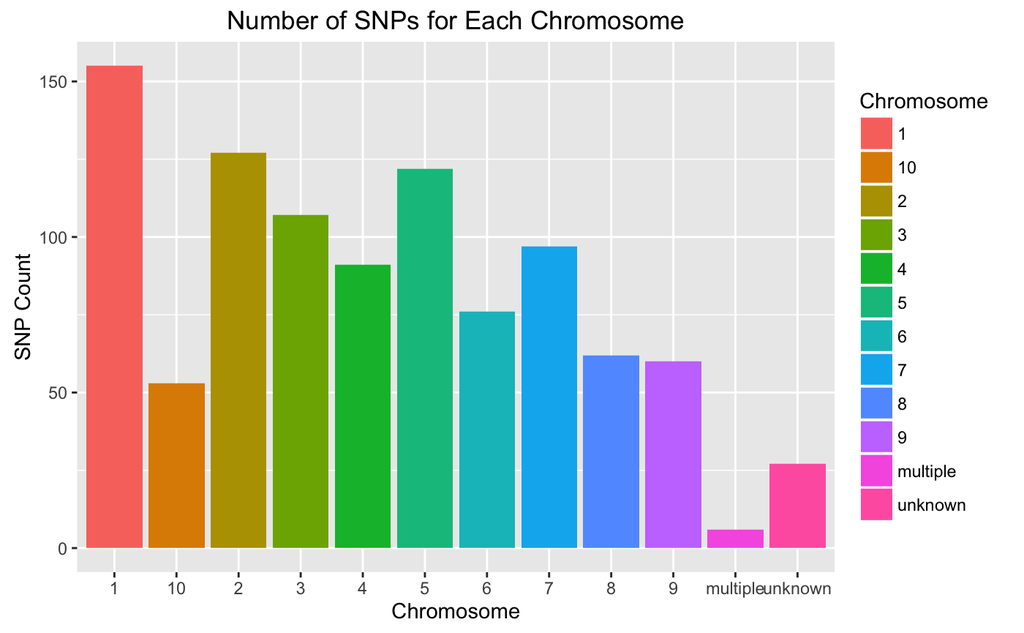

```r
library(ggplot2)
ggplot(meltedposition) +
  geom_bar(aes(x=Chromosome, fill=Chromosome)) +
  ggtitle("Number of SNPs for Each Chromosome") +
  labs(x="Chromosome",y="SNP Count")
```

### Which groups contribute most of these SNPs?

**The dataframe graph comes from the next graphing question**

```r
graphsummary2 <- graph %>%
  group_by(Group, variable, SNPStatus) %>%
  summarise(length(SNPStatus)) #group by Group and SNP status, then total the counts of each different SNP status

colnames(graphsummary2)[4] <- "SNP_Number" #rename column name
```

**Manipulate the dataframe**

```r
graphsummary3 <- dcast(graphsummary2, Group + variable ~SNPStatus, value.var = "SNP_Number") #cast the dataframe so that Heterozygous individuals are counted for each locus in each population in a single column

colnames(graphsummary3)[5] <- "Missing"

Heterozygosity <- graphsummary3 %>%
  group_by(Group, variable) %>%
  summarise(length(Heterozygous[!is.na(Heterozygous)])) #calls whether a locus is heterozygous or not for each group

colnames(Heterozygosity)[3] <- "Heterozygous"

Heterozygositysummed <- Heterozygosity %>%
  group_by(Group) %>%
  count(Heterozygous) #count the number of loci that are heterozygous for each group
```

**Graph**

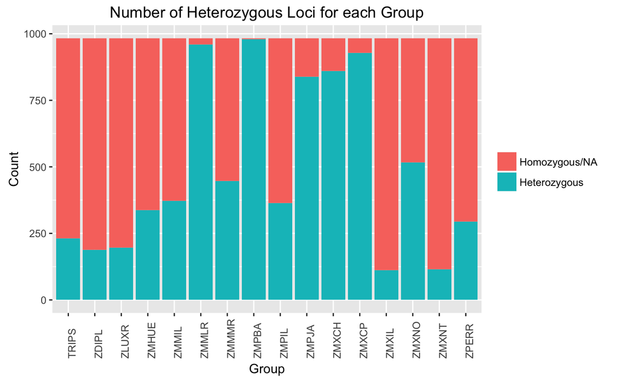

```r
ggplot(Heterozygositysummed[order(Heterozygositysummed$Heterozygous, decreasing = T),], aes(x=Group, y = n, fill=factor(Heterozygous))) +
  geom_bar(stat="identity") +
  ggtitle("Number of Heterozygous Loci for each Group") +
  labs(x="Group",y="Count") +
  theme(legend.title=element_blank(), axis.text.x=element_text(angle = 90, hjust = 0)) +
  scale_fill_discrete(name="Condition",
                         breaks=c("1", "0"),
                         labels=c("Heterozygous", "Homozygous/NA"),
                         guide = guide_legend(reverse=TRUE))
```

### Based on this graph, the groups that are heterozygous at the most loci include: ZMMLR, ZMPBA, ZMPJA, ZMXCH, ZMXCP. These groups contribute most of the SNPs in the dataset.

## Question 2: Missing Data and Amount of Heterozygosity

```r
genotypes <- read.table("fang_et_al_genotypes.txt", header = TRUE, sep="\t", stringsAsFactors = FALSE) #reload the genotype file
meltedgenotypes <- melt(genotypes, c(1,3), c(4:986)) #tidy the data

SNPStatus <- function(x){
  ifelse (x == "?/?", "NA",
  ifelse (x == "A/A"|x == "C/C"|x == "G/G"|x == "T/T", "Homozygous","Heterozygous"))} #function to call

meltedgenotypes$SNPStatus <- lapply(meltedgenotypes$value, FUN=SNPStatus) #apply the function over the column in the reshaped dataset
```

### Next, Sort and Graph

```r
library(gtools)
groupsortgenotypes <- meltedgenotypes[mixedorder(meltedgenotypes$Group),] #sort by group
graph <- tbl_df(groupsortgenotypes) #make a tibble
graph$SNPStatus <- as.factor(unlist(graph$SNPStatus)) #unlist the new column so we can group by it
graphsummary <- graph %>%
  group_by(Group, SNPStatus) %>%
  summarise(length(SNPStatus)) #group by Group and SNP status, then total the counts of each different SNP status
colnames(graphsummary)[3] <- "SNP_Number"
```

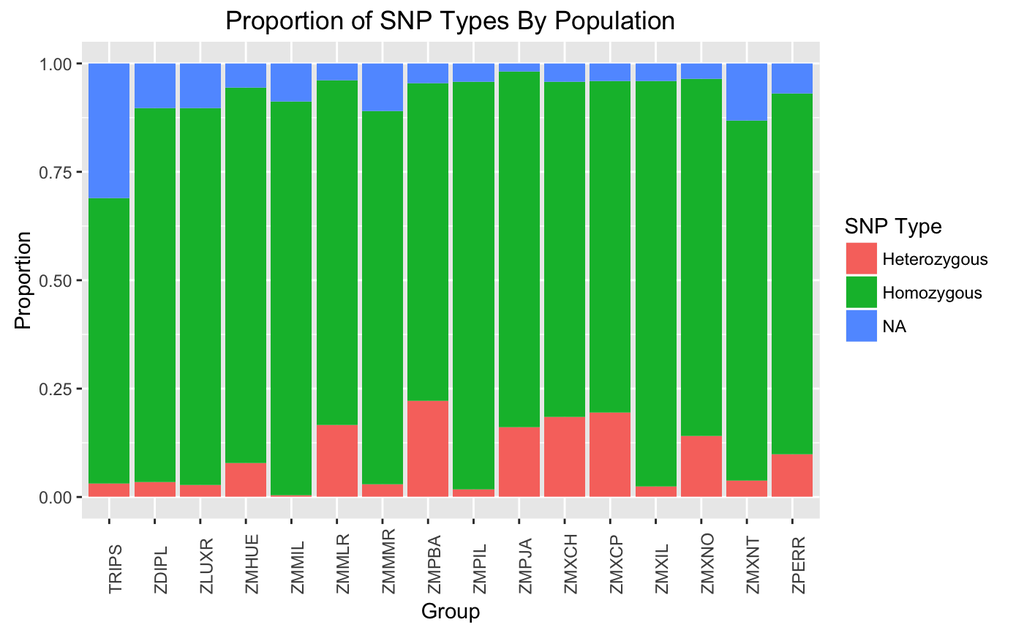

```r
ggplot(graphsummary, aes(x=Group, y = SNP_Number, fill=SNPStatus)) +
  geom_bar(stat="identity", position = "fill") +
  ggtitle("Proportion of SNP Types By Population") +
  labs(x="Group",y="Proportion") +
  theme(axis.text.x=element_text(angle = 90, hjust = 0)) +
  labs(fill='SNP Type')
```

## Question 3: Visualize an aspect of my choice: candidate versus random designation across chromosomes

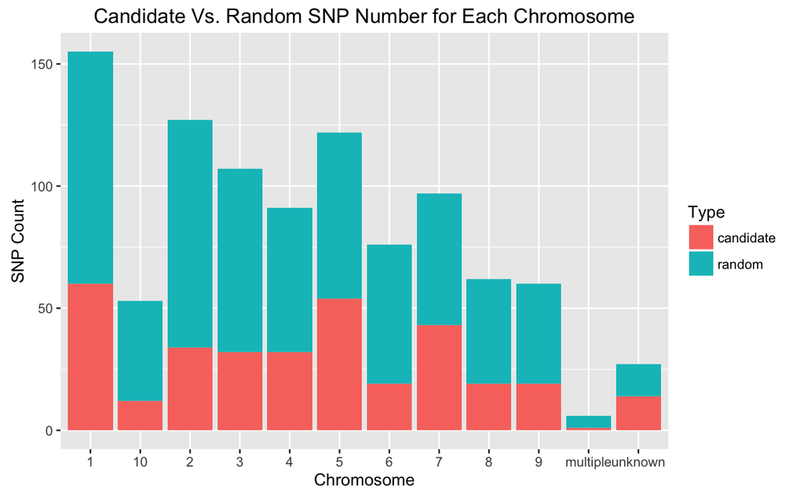

```r
meltedpositionnew <- melt(position, "Chromosome", "candidate.random") #reshape data
colnames(meltedpositionnew)[3] <- "Type" #rename column with info on candidate vs. random
ggplot(meltedpositionnew) +
  geom_bar(aes(x=Chromosome, fill=Type)) +
  ggtitle("Candidate Vs. Random SNP Number for Each Chromosome") +
  labs(x="Chromosome",y="SNP Count")
```